# Project: Ford Gobike Data Analysis

- Introduction
- Gathering Data
- Assesing Data
- Cleaning Data
- Exploratory Data Analysis

## Introduction

In this project, I will analyze the data of a bike rental company Ford GoBike’s Trips in San Francisco. I will use FordGoBike Trip data on the month February 2019 as a reference. After gathering the data, I will clean and analyze it, then give insights and visualizations of the analysis of the dataset.

```python
import pandas as pd
import numpy as np
import seaborn as sns
import matplotlib.pyplot as plt
import time
%matplotlib inline
```

## Gathering Data

At this step, I begin the process of wrangling by gathering the required data.

**1. Ford Gobike Trip Data**

```python
df = pd.read_csv('201902-fordgobike-tripdata.csv')
```

## Assessing Data

After gathering each of the above pieces of data, I will assess them visually and programmatically.

```python
df.sample(3)
```

|  | duration_sec | start_time | end_time | start_station_id | start_station_name | start_station_latitude | start_station_longitude | end_station_id | end_station_name | end_station_latitude | end_station_longitude | bike_id | user_type | member_birth_year | member_gender | bike_share_for_all_trip |
| --- | --- | --- | --- | --- | --- | --- | --- | --- | --- | --- | --- | --- | --- | --- | --- | --- |
| 52833 | 406 | 2019-02-21 16:49:42.5870 | 2019-02-21 16:56:28.8800 | 241.0 | Ashby BART Station | 37.852477 | -122.270213 | 188.0 | Dover St at 57th St | 37.842630 | -122.267738 | 6350 | Subscriber | 1997.0 | Female | No |
| 132989 | 475 | 2019-02-08 20:51:05.8820 | 2019-02-08 20:59:01.1670 | 253.0 | Haste St at College Ave | 37.866418 | -122.253799 | 253.0 | Haste St at College Ave | 37.866418 | -122.253799 | 4882 | Subscriber | 1998.0 | Male | Yes |
| 155846 | 430 | 2019-02-06 08:29:25.2270 | 2019-02-06 08:36:35.7140 | 15.0 | San Francisco Ferry Building (Harry Bridges Pl... | 37.795392 | -122.394203 | 25.0 | Howard St at 2nd St | 37.787522 | -122.397405 | 3391 | Subscriber | 1975.0 | Male | No |

```python
df.shape
```

```
(183412, 16)
```

```python
df.info()
```

```
<class 'pandas.core.frame.DataFrame'>
RangeIndex: 183412 entries, 0 to 183411
Data columns (total 16 columns):
 #   Column                   Non-Null Count   Dtype
---  ------                   --------------   -----
 0   duration_sec             183412 non-null  int64
 1   start_time               183412 non-null  object
 2   end_time                 183412 non-null  object
 3   start_station_id         183215 non-null  float64
 4   start_station_name       183215 non-null  object
 5   start_station_latitude   183412 non-null  float64
 6   start_station_longitude  183412 non-null  float64
 7   end_station_id           183215 non-null  float64
 8   end_station_name         183215 non-null  object
 9   end_station_latitude     183412 non-null  float64
 10  end_station_longitude    183412 non-null  float64
 11  bike_id                  183412 non-null  int64
 12  user_type                183412 non-null  object
 13  member_birth_year        175147 non-null  float64
 14  member_gender            175147 non-null  object
 15  bike_share_for_all_trip  183412 non-null  object
dtypes: float64(7), int64(2), object(7)
memory usage: 22.4+ MB
```

```python
df.describe()
```

|  | duration_sec | start_station_id | start_station_latitude | start_station_longitude | end_station_id | end_station_latitude | end_station_longitude | bike_id | member_birth_year |
| --- | --- | --- | --- | --- | --- | --- | --- | --- | --- |
| count | 183412.000000 | 183215.000000 | 183412.000000 | 183412.000000 | 183215.000000 | 183412.000000 | 183412.000000 | 183412.000000 | 175147.000000 |
| mean | 726.078435 | 138.590427 | 37.771223 | -122.352664 | 136.249123 | 37.771427 | -122.352250 | 4472.906375 | 1984.806437 |
| std | 1794.389780 | 111.778864 | 0.099581 | 0.117097 | 111.515131 | 0.099490 | 0.116673 | 1664.383394 | 10.116689 |
| min | 61.000000 | 3.000000 | 37.317298 | -122.453704 | 3.000000 | 37.317298 | -122.453704 | 11.000000 | 1878.000000 |
| 25% | 325.000000 | 47.000000 | 37.770083 | -122.412408 | 44.000000 | 37.770407 | -122.411726 | 3777.000000 | 1980.000000 |
| 50% | 514.000000 | 104.000000 | 37.780760 | -122.398285 | 100.000000 | 37.781010 | -122.398279 | 4958.000000 | 1987.000000 |
| 75% | 796.000000 | 239.000000 | 37.797280 | -122.286533 | 235.000000 | 37.797320 | -122.288045 | 5502.000000 | 1992.000000 |
| max | 85444.000000 | 398.000000 | 37.880222 | -121.874119 | 398.000000 | 37.880222 | -121.874119 | 6645.000000 | 2001.000000 |

```python
df.duplicated().sum()
```

```
0
```

```python
df.nunique()
```

```
duration_sec                 4752
start_time                 183401
end_time                   183397
start_station_id              329
start_station_name            329
start_station_latitude        334
start_station_longitude       335
end_station_id                329
end_station_name              329
end_station_latitude          335
end_station_longitude         335
bike_id                      4646
user_type                       2
member_birth_year              75
member_gender                   3
bike_share_for_all_trip         2
dtype: int64
```

```python
df.isnull().sum()
```

```
duration_sec                  0
start_time                    0
end_time                      0
start_station_id            197
start_station_name          197
start_station_latitude        0
start_station_longitude       0
end_station_id              197
end_station_name            197
end_station_latitude          0
end_station_longitude         0
bike_id                       0
user_type                     0
member_birth_year          8265
member_gender              8265
bike_share_for_all_trip       0
dtype: int64
```

### Observations:

1. start_station_id and start_station_name are redundant, therefore I will only keep the start station name
2. end_station_id and end_station_name are redundant, therefore I will only keep the end station name
3. I am not interested in latitude and longitude, therefore I will drop those 4 columns
4. Some data are not in their most appropriate data type

## Cleaning Data

```python
df_clean = df.copy()
```

```python
df_clean.drop(['start_station_id','end_station_id','start_station_latitude','start_station_longitude', 'end_station_latitude', 'end_station_longitude'], axis=1, inplace=True)
df_clean.sample(3)
```

|  | duration_sec | start_time | end_time | start_station_name | end_station_name | bike_id | user_type | member_birth_year | member_gender | bike_share_for_all_trip |
| --- | --- | --- | --- | --- | --- | --- | --- | --- | --- | --- |
| 181402 | 232 | 2019-02-01 09:17:19.2170 | 2019-02-01 09:21:11.5000 | Franklin St at 9th St | Lake Merritt BART Station | 1149 | Subscriber | 1982.0 | Male | No |
| 11797 | 1364 | 2019-02-27 17:59:37.7790 | 2019-02-27 18:22:22.0020 | Bancroft Way at Telegraph Ave | Channing Way at San Pablo Ave | 4688 | Subscriber | 1993.0 | Male | No |
| 115550 | 1866 | 2019-02-12 08:13:00.8430 | 2019-02-12 08:44:06.8740 | San Francisco Ferry Building (Harry Bridges Pl... | Hubbell St at 16th St | 2753 | Subscriber | 1978.0 | Other | No |

```python
#master_df.timestamp = pd.to_datetime(master_df.timestamp)
df_clean['start_time'] = pd.to_datetime(df_clean['start_time'])
df_clean['end_time'] = pd.to_datetime(df_clean['end_time'])
df_clean['bike_id'] = df_clean['bike_id'].astype(object)
df_clean['member_birth_year'] = df_clean['member_birth_year'].astype(object)
```

```python
df_clean.info()
```

```
<class 'pandas.core.frame.DataFrame'>
RangeIndex: 183412 entries, 0 to 183411
Data columns (total 10 columns):
 #   Column                   Non-Null Count   Dtype
---  ------                   --------------   -----
 0   duration_sec             183412 non-null  int64
 1   start_time               183412 non-null  datetime64[ns]
 2   end_time                 183412 non-null  datetime64[ns]
 3   start_station_name       183215 non-null  object
 4   end_station_name         183215 non-null  object
 5   bike_id                  183412 non-null  object
 6   user_type                183412 non-null  object
 7   member_birth_year        175147 non-null  object
 8   member_gender            175147 non-null  object
 9   bike_share_for_all_trip  183412 non-null  object
dtypes: datetime64[ns](2), int64(1), object(7)
memory usage: 14.0+ MB
```

```python
df_clean.sample(3)
```

|  | duration_sec | start_time | end_time | start_station_name | end_station_name | bike_id | user_type | member_birth_year | member_gender | bike_share_for_all_trip |
| --- | --- | --- | --- | --- | --- | --- | --- | --- | --- | --- |
| 54678 | 868 | 2019-02-21 12:07:58.044 | 2019-02-21 12:22:26.234 | Broadway at Battery St | 11th St at Natoma St | 5539 | Subscriber | 1982 | Male | No |
| 111538 | 298 | 2019-02-12 17:02:49.747 | 2019-02-12 17:07:47.774 | Folsom St at 9th St | Folsom St at 13th St | 5405 | Subscriber | 1986 | Female | No |
| 154380 | 473 | 2019-02-06 09:52:56.741 | 2019-02-06 10:00:50.092 | Berkeley Civic Center | Bancroft Way at Telegraph Ave | 5443 | Subscriber | 1992 | Female | Yes |

## Exploratory Data Analysis

### Research Question #1: When are most trips taken in terms of day of the week?

```python
df_clean['day'] = pd.DatetimeIndex(df_clean['start_time']).weekday
df_clean['day'].value_counts()
```

```
3    35197
1    31813
2    29641
4    28981
0    26852
6    15523
5    15405
Name: day, dtype: int64
```

```python
day_char = {0:'Monday',1:'Tuesday',2:'Wednesday',3:'Thursday',4:'Friday',5:'Saturday',6:'Sunday'}
df_clean['day'] = df_clean['day'].map(day_char)
```

```python
df_clean['day'].value_counts()
```

```
Thursday     35197
Tuesday      31813
Wednesday    29641
Friday       28981
Monday       26852
Sunday       15523
Saturday     15405
Name: day, dtype: int64
```

```python
df_clean.sample(3)
```

|  | duration_sec | start_time | end_time | start_station_name | end_station_name | bike_id | user_type | member_birth_year | member_gender | bike_share_for_all_trip | day |
| --- | --- | --- | --- | --- | --- | --- | --- | --- | --- | --- | --- |
| 62185 | 1008 | 2019-02-20 16:59:50.964 | 2019-02-20 17:16:39.342 | San Fernando St at 7th St | Ryland Park | 2930 | Customer | NaN | NaN | No | Wednesday |
| 80230 | 2327 | 2019-02-18 15:32:27.720 | 2019-02-18 16:11:15.408 | San Francisco Ferry Building (Harry Bridges Pl... | Powell St BART Station (Market St at 4th St) | 5545 | Customer | NaN | NaN | No | Monday |
| 11647 | 493 | 2019-02-27 18:23:34.210 | 2019-02-27 18:31:47.864 | 11th St at Bryant St | San Francisco Caltrain Station 2 (Townsend St... | 5249 | Subscriber | 1986 | Male | No | Wednesday |

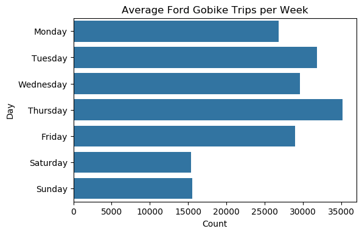

```python
#Plotting of the trips taken in terms of day of the week

day_order = ['Monday', 'Tuesday', 'Wednesday', 'Thursday', 'Friday', 'Saturday', 'Sunday']
plt.figure(dpi=100);
sns.countplot(y="day",data=df_clean, color=sns.color_palette()[0],order=day_order);
plt.title('Average Ford Gobike Trips per Week')
plt.xlabel('Count')
plt.ylabel('Day');
```

### Research Question #2: What is the most common user type (customer vs subscriber) of Ford Gobike?

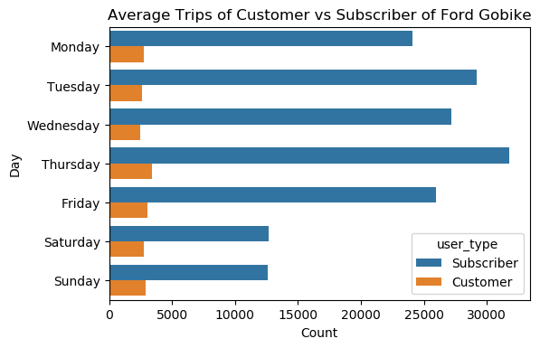

```python
plt.figure(dpi=100);
sns.countplot(y="day", hue = 'user_type', data=df_clean, order = day_order, hue_order = ['Subscriber', 'Customer']);
plt.title('Average Trips of Customer vs Subscriber of Ford Gobike')
plt.xlabel('Count')
plt.ylabel('Day');
```

From the plot above, most of the users of Ford Gobike are subscribers instead of customers. On weekdays, subscribers use Ford Gobike at least 8 times as much as customers do. On weekends, subscribers use Ford Gobike around 4 times more often than customers do. There is a large difference between the average bike usage of subscribers in weekdays and weekends, but the usage of customers are almost the same everyday. However, both customers and subscribers use the bike most oftenly on Thursdays, which is the day with the highest average trips in a week.

### Research Question #3: When are most trips taken in terms of time of the day?

```python
df_clean['time'] = pd.DatetimeIndex(df_clean['start_time']).time
df_clean['hour'] = df_clean['start_time'].apply(lambda time: time.hour)
```

```python
df_clean.head()
```

|  | duration_sec | start_time | end_time | start_station_name | end_station_name | bike_id | user_type | member_birth_year | member_gender | bike_share_for_all_trip | day | time | hour |
| --- | --- | --- | --- | --- | --- | --- | --- | --- | --- | --- | --- | --- | --- |
| 0 | 52185 | 2019-02-28 17:32:10.145 | 2019-03-01 08:01:55.975 | Montgomery St BART Station (Market St at 2nd St) | Commercial St at Montgomery St | 4902 | Customer | 1984 | Male | No | Thursday | 17:32:10.145000 | 17 |
| 1 | 42521 | 2019-02-28 18:53:21.789 | 2019-03-01 06:42:03.056 | The Embarcadero at Steuart St | Berry St at 4th St | 2535 | Customer | NaN | NaN | No | Thursday | 18:53:21.789000 | 18 |
| 2 | 61854 | 2019-02-28 12:13:13.218 | 2019-03-01 05:24:08.146 | Market St at Dolores St | Powell St BART Station (Market St at 4th St) | 5905 | Customer | 1972 | Male | No | Thursday | 12:13:13.218000 | 12 |
| 3 | 36490 | 2019-02-28 17:54:26.010 | 2019-03-01 04:02:36.842 | Grove St at Masonic Ave | Central Ave at Fell St | 6638 | Subscriber | 1989 | Other | No | Thursday | 17:54:26.010000 | 17 |
| 4 | 1585 | 2019-02-28 23:54:18.549 | 2019-03-01 00:20:44.074 | Frank H Ogawa Plaza | 10th Ave at E 15th St | 4898 | Subscriber | 1974 | Male | Yes | Thursday | 23:54:18.549000 | 23 |

```python
df_clean['hour00'] = (df_clean['hour'].astype(str) + '.00')
```

```python
df_clean.sample(3)
```

|  | duration_sec | start_time | end_time | start_station_name | end_station_name | bike_id | user_type | member_birth_year | member_gender | bike_share_for_all_trip | day | time | hour | hour00 |
| --- | --- | --- | --- | --- | --- | --- | --- | --- | --- | --- | --- | --- | --- | --- |
| 119756 | 1063 | 2019-02-11 17:26:43.997 | 2019-02-11 17:44:27.071 | 22nd St Caltrain Station | 24th St at Bartlett St | 1709 | Subscriber | 1996 | Female | No | Monday | 17:26:43.997000 | 17 | 17.00 |
| 77723 | 891 | 2019-02-19 05:18:51.744 | 2019-02-19 05:33:42.978 | The Embarcadero at Sansome St | Raymond Kimbell Playground | 6545 | Subscriber | 1997 | Male | No | Tuesday | 05:18:51.744000 | 5 | 5.00 |
| 92547 | 696 | 2019-02-15 18:42:01.134 | 2019-02-15 18:53:37.225 | 22nd St at Dolores St | Page St at Scott St | 5319 | Subscriber | 1993 | Female | No | Friday | 18:42:01.134000 | 18 | 18.00 |

```python
df_clean['hour00'].value_counts().head(10)
```

```
17.00    21864
8.00     21056
18.00    16827
9.00     15903
16.00    14169
7.00     10614
19.00     9881
15.00     9174
12.00     8724
13.00     8551
Name: hour00, dtype: int64
```

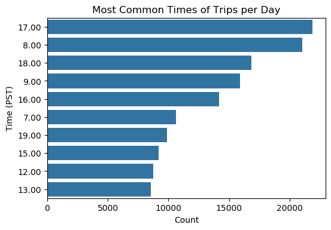

```python
plt.figure(dpi=100);
sns.countplot(y="hour00", data=df_clean, color=sns.color_palette()[0],
              order=df_clean['hour00'].value_counts().iloc[:10].index);
plt.title('Most Common Times of Trips per Day')
plt.xlabel('Count')
plt.ylabel('Time (PST)');
```

```python
category = []

def time_cat(row):
    if (row['hour'] >= 12) & (row['hour'] <= 17):
        category.append('afternoon')
    elif (row['hour'] >= 18) & (row['hour'] <= 23):
        category.append('night')
    else:
        category.append('morning')

df_clean.apply(time_cat, axis=1)
df_clean['period'] = category
```

```python
df_clean['period'].value_counts()
```

```
afternoon    70634
morning      70465
night        42313
Name: period, dtype: int64
```

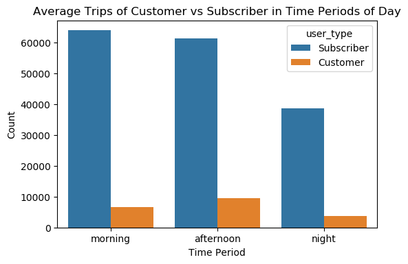

```python
plt.figure(dpi=100);
sns.countplot(x="period", hue = 'user_type', data=df_clean, order = ['morning', 'afternoon', 'night'], hue_order = ['Subscriber', 'Customer']);
plt.title('Average Trips of Customer vs Subscriber in Time Periods of Day')
plt.xlabel('Time Period')
plt.ylabel('Count');
```

After grouping the time of day into three time periods, i.e. morning (00:00 - 11:59), afternoon (12:00 - 17:59), and night (18:00 - 23:59), and differentiating between customer and subscriber, the two most common time period of trips for subscribers are morning and afternoon, which both have above 60000 trips on average. These are significantly higher than the average number of trips of subscribers at night, which is slightly under 40000 trips. The most common time period for customers is afternoon, with around 10000 trips on average. Both subscribers and customers have the lowest number of trips at night.

### Research Question #4: How long does the average trip take?

```python
df['duration_sec'].value_counts().max()
```

```
311
```

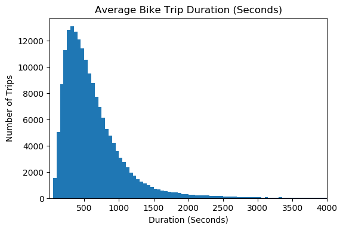

```python
plt.figure(dpi=100);
bin_edges = np.arange(0, df_clean['duration_sec'].max() + 100 , 50)
plt.hist(data = df_clean , x = 'duration_sec', bins = bin_edges)
ticks =  [ 500,1000,1500,2000,2500,3000,3500,4000]
labels = ['{}'.format(v) for v in ticks]
plt.xticks(ticks,labels)
plt.xlim(0,4000)
plt.title('Average Bike Trip Duration (Seconds)')
plt.xlabel('Duration (Seconds)')
plt.ylabel('Number of Trips');
```

```python
df_clean['duration_min'] = df_clean['duration_sec'] / 60
```

```python
df_clean['duration_min'].describe()
```

```
count    183412.000000
mean         12.101307
std          29.906496
min           1.016667
25%           5.416667
50%           8.566667
75%          13.266667
max        1424.066667
Name: duration_min, dtype: float64
```

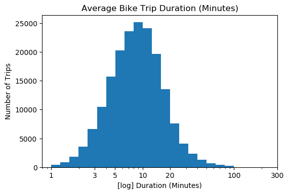

```python
#Log transforming to better understand the data
plt.figure(dpi=100);
bins = 10**np.arange(0 , 2 + 0.1 , 0.1)
ticks =  [ 1 ,3, 5, 10, 20, 100, 300]
labels = ['{}'.format(v) for v in ticks]
plt.hist(data = df_clean , x = 'duration_min', bins = bins);
plt.xscale('log');
plt.xticks(ticks,labels);
plt.xlabel('[log] Duration (Minutes)');
plt.title('Average Bike Trip Duration (Minutes)');
plt.ylabel('Number of Trips');
```

### Research Question #5: What are the top 10 stations with the most trips?

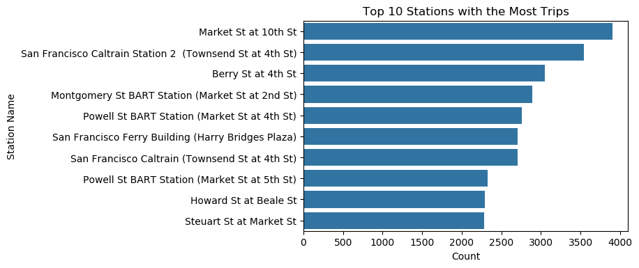

```python
plt.figure(dpi=100);
sns.countplot(y="start_station_name", data=df_clean, color=sns.color_palette()[0],
              order=df_clean['start_station_name'].value_counts().iloc[:10].index);
plt.title('Top 10 Stations with the Most Trips')
plt.xlabel('Count')
plt.ylabel('Station Name');
```

### Analysis of Top 5 Stations with the Most Trips

```python
df_clean['age'] = df['member_birth_year'].apply(lambda x: 2020-x)
```

```python
top5_stations = df_clean['start_station_name'].value_counts().iloc[:5].index
df_top5 = df_clean.loc[df_clean['start_station_name'].isin(top5_stations)]
```

```python
df_top5.head()
```

|  | duration_sec | start_time | end_time | start_station_name | end_station_name | bike_id | user_type | member_birth_year | member_gender | bike_share_for_all_trip | day | time | hour | hour00 | period | duration_min | age |
| --- | --- | --- | --- | --- | --- | --- | --- | --- | --- | --- | --- | --- | --- | --- | --- | --- | --- |
| 0 | 52185 | 2019-02-28 17:32:10.145 | 2019-03-01 08:01:55.975 | Montgomery St BART Station (Market St at 2nd St) | Commercial St at Montgomery St | 4902 | Customer | 1984 | Male | No | Thursday | 17:32:10.145000 | 17 | 17.00 | afternoon | 869.750000 | 36.0 |
| 38 | 1066 | 2019-02-28 23:31:16.139 | 2019-02-28 23:49:02.792 | Market St at 10th St | 29th St at Church St | 5938 | Subscriber | 1992 | Female | No | Thursday | 23:31:16.139000 | 23 | 23.00 | night | 17.766667 | 28.0 |
| 54 | 401 | 2019-02-28 23:30:52.471 | 2019-02-28 23:37:33.955 | Market St at 10th St | Victoria Manalo Draves Park | 5407 | Subscriber | 1990 | Female | No | Thursday | 23:30:52.471000 | 23 | 23.00 | night | 6.683333 | 30.0 |
| 63 | 239 | 2019-02-28 23:28:42.709 | 2019-02-28 23:32:41.769 | Montgomery St BART Station (Market St at 2nd St) | Bryant St at 2nd St | 5731 | Subscriber | 1986 | Male | No | Thursday | 23:28:42.709000 | 23 | 23.00 | night | 3.983333 | 34.0 |
| 85 | 73 | 2019-02-28 23:17:06.483 | 2019-02-28 23:18:19.711 | San Francisco Caltrain Station 2 (Townsend St... | Townsend St at 5th St | 5012 | Subscriber | 1995 | Male | No | Thursday | 23:17:06.483000 | 23 | 23.00 | night | 1.216667 | 25.0 |

### Total Trips by Time Periods of Day of Top 5 Stations

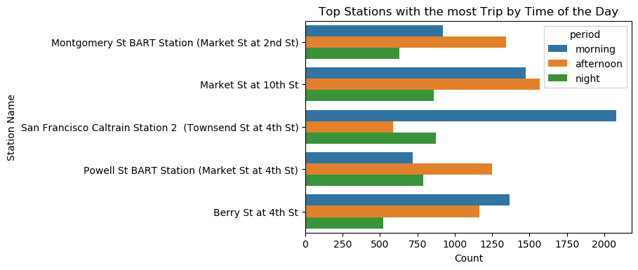

```python
plt.figure(dpi=100);
sns.countplot(data=df_top5, y='start_station_name', hue='period', hue_order = ['morning', 'afternoon', 'night'])
plt.title('Top Stations with the most Trip by Time of the Day')
plt.xlabel('Count')
plt.ylabel('Station Name');
```

After categorizing the trips by time periods of day for the top 5 stations with the most trips overall, it shows that Market St at 10th St as the station with the most number of trips is only the top station in the afternoon compared to the other 4 stations. In the morning, the station with the most number of trips is San Francisco Caltrain Station 2 (Townsend St at 4th St) with around 2100 total trips in the month. The same station also has the most number of trips at night with around 850 trips, which is similar to the number of trips at Market St at 10th St. Among the 5 stations, the most busy time periods are either morning or afternoon.

### Relationship between Age and Duration

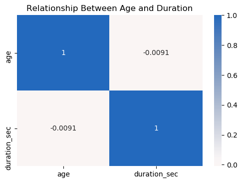

```python
plt.figure(dpi=100);
sns.heatmap(df_top5[['age', 'duration_sec']].corr(), annot = True,cmap = 'vlag_r',center = 0)
plt.title('Relationship Between Age and Duration');
```

Based on the correlation plot above, there appears to be no correlation between the age of user and the duration (in seconds) of the bike trip.

### Average Trip Duration in Minutes by Gender of Top 5 Stations

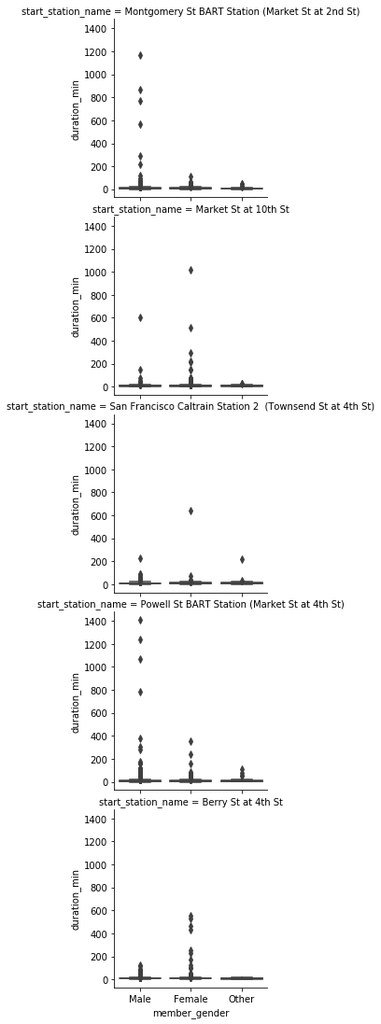

```python
g = sns.FacetGrid(data = df_top5, col = 'start_station_name', margin_titles=True, col_wrap = 1)
g.map(sns.boxplot, 'member_gender', 'duration_min');
```

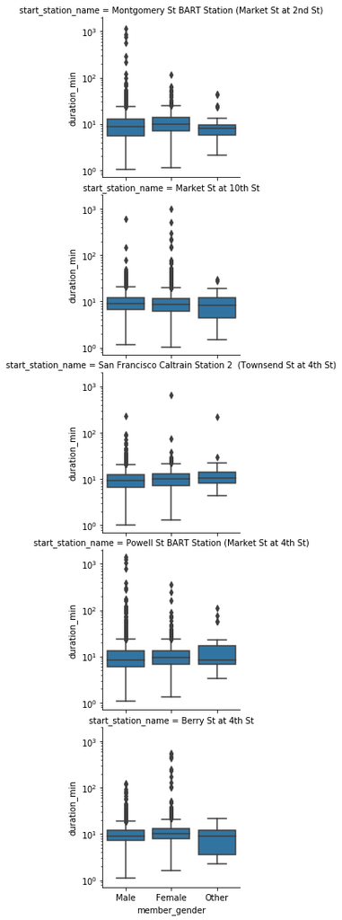

```python
g = sns.FacetGrid(data = df_top5, col = 'start_station_name', margin_titles=True, col_wrap = 1)
g.map(sns.boxplot, 'member_gender', 'duration_min');
plt.yscale('log')
```

Because the data is heavily skewed and has a lot of outliers, I plotted the average trip duration in minutes in a logarithmic scale. In the resulting plot, there appears to be no substantial difference of average duration of bike trips between members who classify themselves as males, females, or others which is consistent in all five stations. The average duration is around 10 minutes for all genders and stations. Most of the trips take under 10 minutes for all genders and stations.

### Age of Ford Gobike Users of Top 5 Stations by Gender

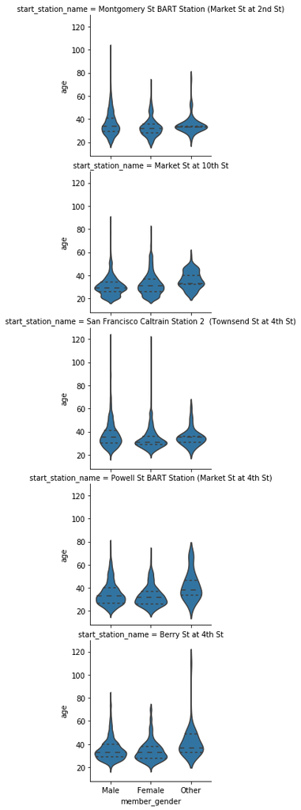

```python
g = sns.FacetGrid(data = df_top5, col = 'start_station_name', margin_titles=True, col_wrap = 1)
g.map(sns.violinplot, 'member_gender', 'age', inner='quartile');
```

Based on the plot of the bike users’ age categorized by gender of the top 5 stations, most of the bike’s customer are around 25 to 40 years old. There is no consistent difference of age across the users’ gender, and the slight differences in average age are different for each stations.

### Average Trip Duration in Minutes per Day by User Types

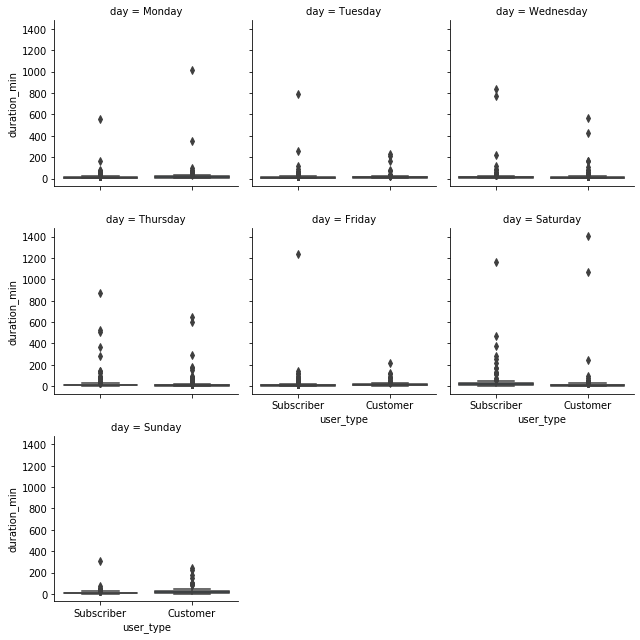

```python
g = sns.FacetGrid(data = df_top5, col = 'day', margin_titles=True, col_wrap = 3, col_order = day_order)
g.map(sns.boxplot, 'user_type', 'duration_min');
```

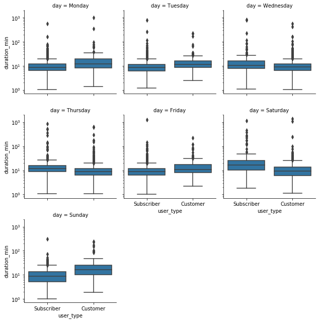

```python
g = sns.FacetGrid(data = df_top5, col = 'day', margin_titles=True, col_wrap = 3, col_order = day_order)
g.map(sns.boxplot, 'user_type', 'duration_min');
plt.yscale('log')
```

Because the data of average trip duration is heavily skewed and has a lot of outliers like the case before, I plotted the average trip duration in minutes in a logarithmic scale. This results to a plot of average trip durations for Subscribers vs Customers for each day in the week. There is no consistent difference (i.e. customers always have a higher average duration time or vice versa) accross the days of the week, hence a conclusive statement cannot be made.